# Portfolio 3

Veethacheng Thao

In this deliverable I would be doing some more visualizing and improvement of my findings from deliverable 2. To do this we would need to load the previous information.

```r
install.packages("tidyverse", repos = "http://cran.us.r-project.org")
library("tidyverse")
library("knitr")
purl("portfolio2.Rmd", output = "part2.r")
```

```
##
##
## processing file: portfolio2.Rmd
```

[output not shown]

```
## output file: part2.r
```

```
## [1] "part2.r"
```

```r
source("part1.r")
```

## Fixing up Deliverable 1

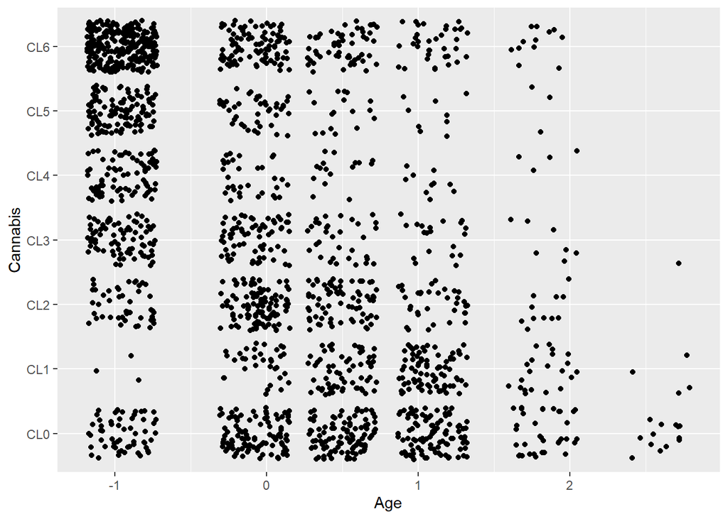

```r
ggplot(drugs, aes(Age, Cannabis)) + geom_jitter()
```

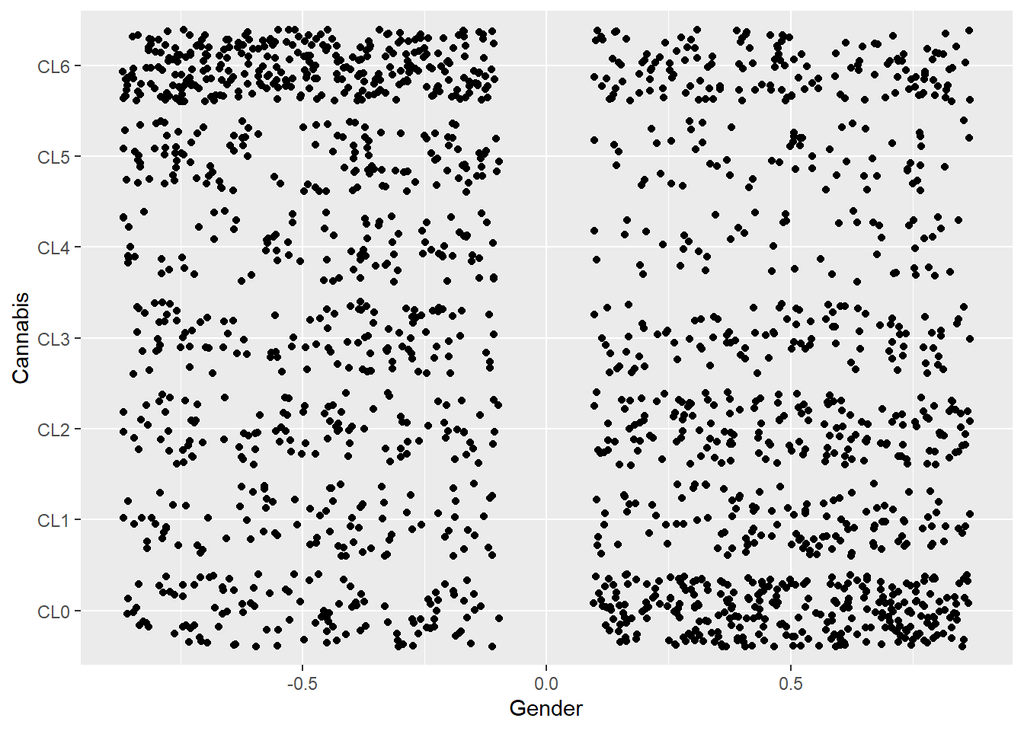

```r
ggplot(drugs, aes(Gender, Cannabis)) +  geom_jitter()
```

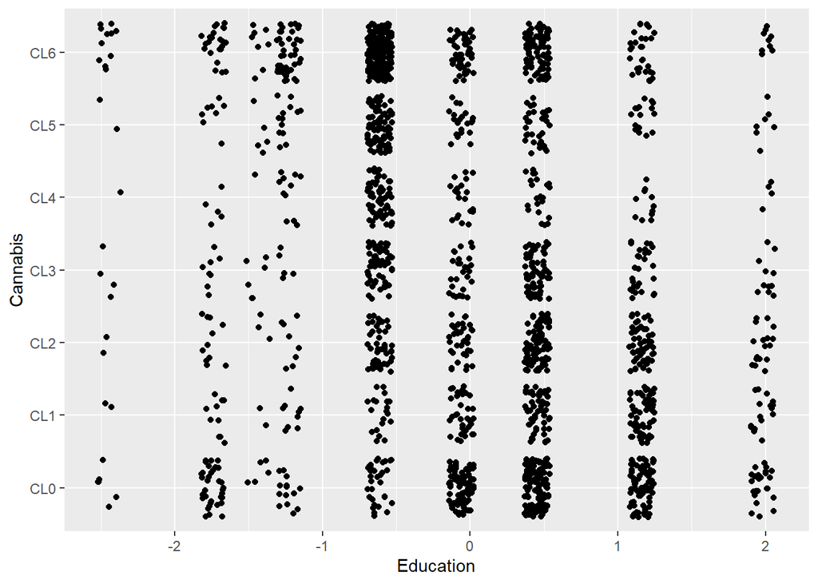

```r
ggplot(drugs, aes(Education, Cannabis)) +  geom_jitter()
```

After peer review, the reviewer stated that adding summary to my visuals would help, so here are some findings of these graphs. These graphs gives users the information of the drug cannabis. The first visual shows that the all age group uses this drug but its mainly group ages from 18 - 54. The second visual shows that guys are the most recent users of this drug. And lastly this visual shows that the education group that uses this drug the most is people that have some college background to people that have master’s degree. This gives me the insight that maybe these people are away from home, that it is probably why they have the freedom to do drugs and not have anyone telling them to not do drugs.

And to fix the format issue of the values:

#### Age:

-0.95197 is ages 18 - 24

-0.07854 is ages 25 - 34

0.49788 is ages 35 - 44

1.09449 is ages 45 - 54

1.82213 is ages 55 - 64

2.59171 is ages 65+

#### Gender:

0.48246 is Female

-0.48246 is Male

#### Education:

-2.43591 Left School Before 16 years

-1.73790 Left School at 16 years

-1.43719 Left School at 17 years

-1.22751 Left School at 18 years

-0.61113 Some College,No Certificate Or Degree

-0.05921 Professional Certificate/ Diploma

0.45468 University Degree

1.16365 Masters Degree

1.98437 Doctorate Degree

#### Time of drug used:

CL0 Never Used

CL1 Used over a Decade Ago

CL2 Used in Last Decade

CL3 Used in Last Year

CL4 Used in Last Month

CL5 Used in Last Week

CL6 Used in Last Day

## Vizualizing Deliverable 2

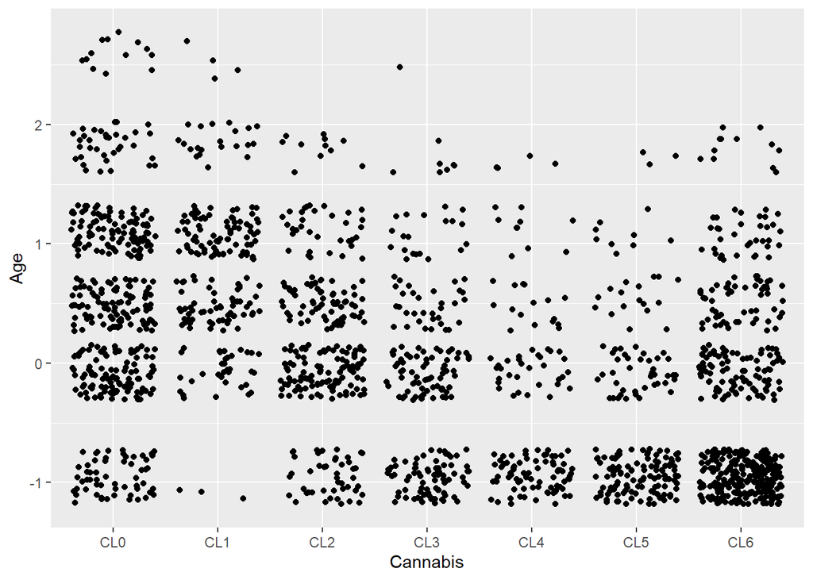

```r
ggplot(drugs, aes(x = Cannabis , y = Age)) + geom_jitter()
```

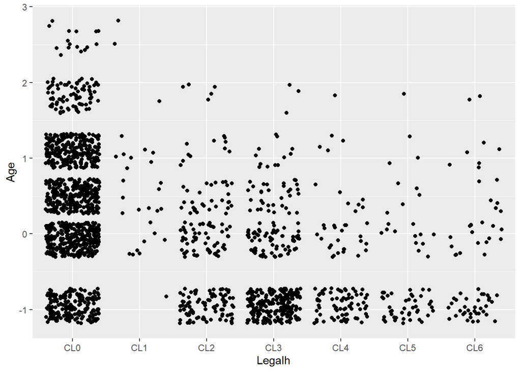

```r
ggplot(drugs, aes(x = Legalh , y = Age)) + geom_jitter()
```

## Improvement on Deliverable 2

This step is going to involve improving my models.

```r
library("caret")
sample <- createDataPartition(drugs$Age, p = .70, list = FALSE)
train <- drugs[sample,]
test <- drugs[-sample,]
train_model <- lm(Age ~ Coke + Meth + Crack + Mushrooms + Alcohol + Amphet + Amyl + Benzos + Caff + Cannabis + Choc + Ecstasy + Heroin + Ketamine + Legalh + LSD + Nicotine + Semer + VSA, data = train)
summary(train_model)
```

```
##
## Call:
## lm(formula = Age ~ Coke + Meth + Crack + Mushrooms + Alcohol +
##     Amphet + Amyl + Benzos + Caff + Cannabis + Choc + Ecstasy +
##     Heroin + Ketamine + Legalh + LSD + Nicotine + Semer + VSA,
##     data = train)
##
## Residuals:
##      Min       1Q   Median       3Q      Max
## -1.66840 -0.36789 -0.05315  0.34476  2.43338
##
## Coefficients:
##               Estimate Std. Error t value Pr(>|t|)
## (Intercept)   0.453937   0.241339   1.881 0.060224 .
## CokeCL1       0.363705   0.086524   4.204 2.82e-05 ***
## CokeCL2       0.202595   0.073725   2.748 0.006085 **
## CokeCL3       0.083709   0.071712   1.167 0.243322
## CokeCL4       0.116288   0.098138   1.185 0.236274
## CokeCL5      -0.131813   0.136122  -0.968 0.333066
## CokeCL6      -0.209366   0.202122  -1.036 0.300484
## MethCL1      -0.193714   0.143124  -1.353 0.176158
## MethCL2      -0.083250   0.087623  -0.950 0.342255
## MethCL3      -0.146918   0.076370  -1.924 0.054619 .
## MethCL4      -0.054950   0.117550  -0.467 0.640254
## MethCL5      -0.064081   0.121552  -0.527 0.598159
## MethCL6      -0.269570   0.107953  -2.497 0.012653 *
## CrackCL1      0.170367   0.109935   1.550 0.121472
## CrackCL2      0.151042   0.089578   1.686 0.092025 .
## CrackCL3      0.012551   0.123364   0.102 0.918979
## CrackCL4      0.198862   0.267618   0.743 0.457576
## CrackCL5      0.208608   0.250557   0.833 0.405246
## CrackCL6      0.373310   0.469138   0.796 0.426342
## MushroomsCL1  0.038356   0.076813   0.499 0.617625
## MushroomsCL2 -0.029562   0.069263  -0.427 0.669593
## MushroomsCL3 -0.064000   0.070398  -0.909 0.363473
## MushroomsCL4 -0.100596   0.095891  -1.049 0.294354
## MushroomsCL5 -0.063478   0.145628  -0.436 0.662995
## MushroomsCL6  0.305116   0.417092   0.732 0.464596
## AlcoholCL1    0.514141   0.181447   2.834 0.004680 **
## AlcoholCL2    0.083394   0.168000   0.496 0.619710
```

[output cut: 74 more lines]

```
## NicotineCL6   0.030883   0.059289   0.521 0.602535
## SemerCL2     -0.188830   0.393415  -0.480 0.631332
## SemerCL3     -0.141398   0.651629  -0.217 0.828251
## VSACL1       -0.013995   0.065662  -0.213 0.831254
## VSACL2       -0.227741   0.076803  -2.965 0.003084 **
## VSACL3       -0.366534   0.104750  -3.499 0.000484 ***
## VSACL4       -0.457872   0.223740  -2.046 0.040928 *
## VSACL5       -0.065808   0.198438  -0.332 0.740228
## VSACL6       -0.265933   0.295728  -0.899 0.368699
## ---
## Signif. codes:  0 '***' 0.001 '**' 0.01 '*' 0.05 '.' 0.1 ' ' 1
##
## Residual standard error: 0.6152 on 1211 degrees of freedom
## Multiple R-squared:  0.5506, Adjusted R-squared:  0.5101
## F-statistic: 13.61 on 109 and 1211 DF,  p-value: < 2.2e-16
```

```r
train_model <- lm(Age ~ Cannabis + Legalh, data = train)
summary(train_model)
```

```
##
## Call:
## lm(formula = Age ~ Cannabis + Legalh, data = train)
##
## Residuals:
##     Min      1Q  Median      3Q     Max
## -1.7325 -0.4685 -0.1747  0.4963  2.4955
##
## Coefficients:
##             Estimate Std. Error t value Pr(>|t|)
## (Intercept)  0.45058    0.04325  10.419  < 2e-16 ***
## CannabisCL1  0.32992    0.07531   4.381 1.28e-05 ***
## CannabisCL2 -0.16405    0.06897  -2.378 0.017530 *
## CannabisCL3 -0.35441    0.07926  -4.472 8.43e-06 ***
## CannabisCL4 -0.57899    0.09234  -6.270 4.88e-10 ***
## CannabisCL5 -0.57841    0.08579  -6.742 2.34e-11 ***
## CannabisCL6 -0.44903    0.07074  -6.347 3.01e-10 ***
## LegalhCL1    0.55821    0.16877   3.308 0.000967 ***
## LegalhCL2   -0.41668    0.07619  -5.469 5.41e-08 ***
## LegalhCL3   -0.57960    0.06472  -8.955  < 2e-16 ***
## LegalhCL4   -0.54938    0.09183  -5.982 2.83e-09 ***
## LegalhCL5   -0.43905    0.12274  -3.577 0.000360 ***
## LegalhCL6   -0.24897    0.11814  -2.107 0.035275 *
## ---
## Signif. codes:  0 '***' 0.001 '**' 0.01 '*' 0.05 '.' 0.1 ' ' 1
##
## Residual standard error: 0.7368 on 1308 degrees of freedom
## Multiple R-squared:  0.3036, Adjusted R-squared:  0.2972
## F-statistic: 47.52 on 12 and 1308 DF,  p-value: < 2.2e-16
```

## OPERATIONALIZATION

To operationalize my finding would involve in some sort of drug education in all area of group age. Although, there are signs of the age group of 18 - 24 being the most active in drug activity. Cannabis being the top drug this group currently or have use recently during drug activity. Taking this to account, deeper research into this particular drug and finding how it affects a person to better educate people on this drug.

After the peer review, adding more research into other drugs would be beneficial to help operationalize. Having more knowlegde of all these drugs would greatly help with educating people.